# Lab02 - Prediccion y Clasificacion

Configuracion de librerias y Ruta de trabajo

```r
library(dplyr)
library(caTools)
library(class)
library(e1071)
```

```r
library(rpart)
library(rpart.plot)
library(tree)
library(randomForest)
#current_dir <- dirname(rstudioapi::getSourceEditorContext()$path)
#setwd(current_dir)
```

## Cargar el set de datos

Vamos a continuar usando el set de datos que limpiamos y transformamos en el laboratorio pasado en donde se registran los atributos de varias botellas de vino junto con su calidad. De esta forma usaremos el mismo dataset a lo largo de todo el flujo del curso como si se tratara de un proyecto real!

```r
wine_df <- read.csv('data/winequality-white_clean.csv', header = T, fileEncoding = 'utf-8')
glimpse(wine_df)
```

```
## Rows: 4,461
## Columns: 12
## $ fixed_acidity        <dbl> 7.0, 6.3, 8.1, 7.2, 7.2, 8.1, 6.2, 7.0, 6.3, 8...
## $ volatile_acidity     <dbl> 0.27, 0.30, 0.28, 0.23, 0.23, 0.28, 0.32, 0.27...
## $ citric_acid          <dbl> 0.36, 0.34, 0.40, 0.32, 0.32, 0.40, 0.16, 0.36...
## $ residual_sugar       <dbl> 20.7, 1.6, 6.9, 8.5, 8.5, 6.9, 7.0, 20.7, 1.6,...
## $ chlorides            <dbl> 0.045, 0.049, 0.050, 0.058, 0.058, 0.050, 0.04...
## $ free_sulfur_dioxide  <dbl> 45, 14, 30, 47, 47, 30, 30, 45, 14, 28, 17, 16...
## $ total_sulfur_dioxide <dbl> 170, 132, 97, 186, 186, 97, 136, 170, 132, 129...
## $ density              <dbl> 1.0010, 0.9940, 0.9951, 0.9956, 0.9956, 0.9951...
## $ pH                   <dbl> 3.00, 3.30, 3.26, 3.19, 3.19, 3.26, 3.18, 3.00...
## $ sulphates            <dbl> 0.45, 0.49, 0.44, 0.40, 0.40, 0.44, 0.47, 0.45...
## $ alcohol              <dbl> 8.8, 9.5, 10.1, 9.9, 9.9, 10.1, 9.6, 8.8, 9.5,...
## $ score                <dbl> 6.15, 6.67, 6.48, 6.74, 6.45, 6.26, 6.70, 6.41...
```

## 2a. Prediccion

Ya hemos visto los conceptos basicos de una regresion: - Aprendizaje **supervisado** - Predecir una variable **continua** - Se busca encontrar los **pesos** de las variables para validar cada una de ellas como influye en nuestra variable final

```r
x = wine_df[, !names(wine_df) %in% c("score")]
y = wine_df['score']
```

```r
set.seed(42)
sample = sample.split(wine_df[,1], SplitRatio = .75)
train_df = subset(wine_df, sample == TRUE)
test_df  = subset(wine_df, sample == FALSE)
```

### OLS (Ordinary Least Squares)

Llamado asi porque busca los coeficientes de la ecuacion que minimizen la suma de las distancias verticales entre los datos y el modelo. Para aplicar este modelo se debe validar que no haya multicolinealidad entre las variables predictivas, pues no la detecta facilmente.

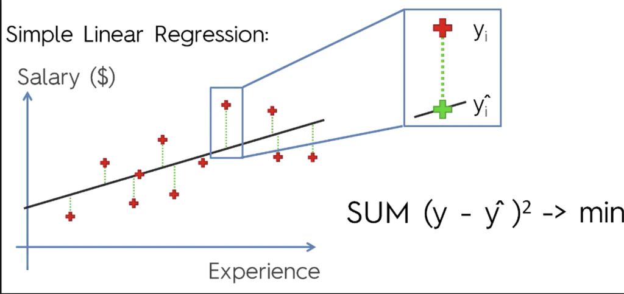

- **Precision:** Alta, para variables no correlacionadas (Condiciones para OLS [aqui](https://statisticsbyjim.com/regression/ols-linear-regression-assumptions))
- **Velocidad:** Rapido
- **Explicativo:** Mucho (Peso/Importancia de cada variable)
- **Sensible a cambios:** Poco, OLS crea una estimacion genralizada a todos los puntos, un solo valor atipico modificara los pesos de las variables pero no drasticamente, pues seguira convergiendo a los demas puntos
- **Deteministico**: Si

```r
names(wine_df)
```

```
##  [1] "fixed_acidity"        "volatile_acidity"     "citric_acid"
##  [4] "residual_sugar"       "chlorides"            "free_sulfur_dioxide"
##  [7] "total_sulfur_dioxide" "density"              "pH"
## [10] "sulphates"            "alcohol"              "score"
```

Empecemos con un modelo sencillo: una regresion sobre una sola variable. Elija una de las columnas predictivas y usemosla como onica variable predictiva. *Ej: chlorides*

```r
model_ols <- lm(formula=score ~ chlorides, data = wine_df)
```

En el caso de **una** variable predictiva y una variable objetivo, podemos ver graficamente el comportamiento de nuestro modelo:

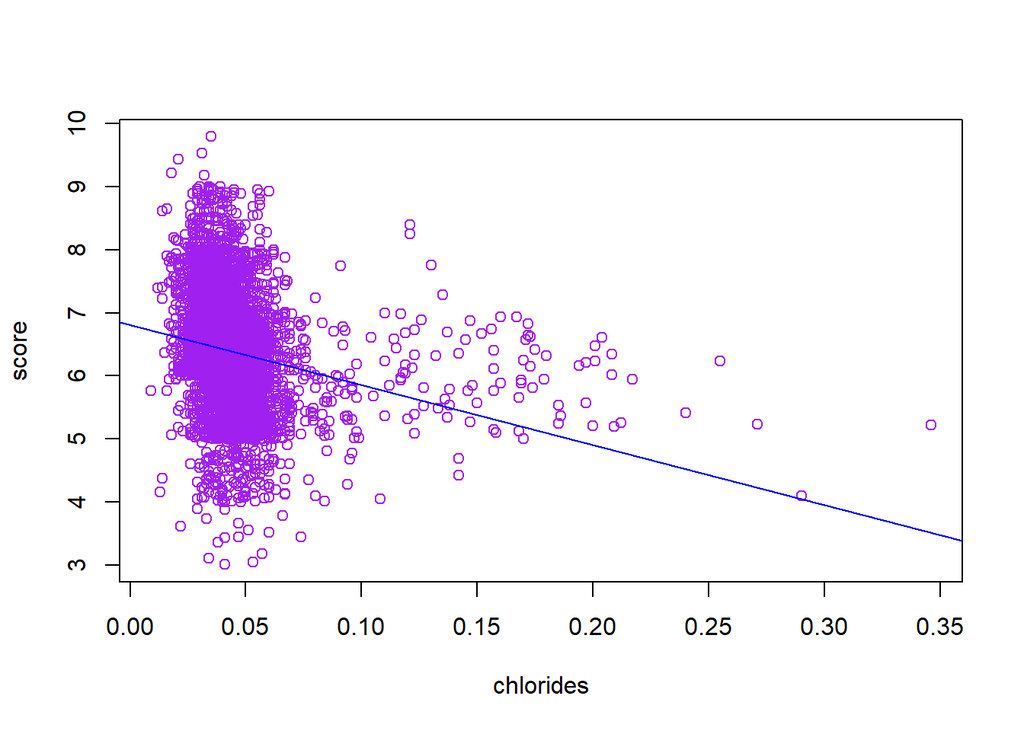

```r
plot(wine_df$chlorides, wine_df$score, type='p', col='purple', xlab='chlorides', ylab='score')
abline(model_ols, col = 'blue')
```

Con una sola variable es posible que el modelo no se ajuste correctamente a los datos, podemos ver que daria predicciones erradas. Podemos incluir otras variables al modelo que nos permitan darle mas flexibilidad a l ecuacion

En el parametro para *lm()* se le indica al modelo que necesitamos una funcion de la forma: > Y ~ X1 + X2 + X3 + X4 + … + Xn

En donde Y es nuestra variale objetivo y cada Xi son las variables predictivas para las que se debe buscar un peso en la ecuacion.

```r
model_ols <- lm(formula=score ~ fixed_acidity + volatile_acidity + citric_acid + residual_sugar +
                chlorides + free_sulfur_dioxide + total_sulfur_dioxide + density + pH+
                sulphates + alcohol, data = wine_df)
model_ols
```

```
##
## Call:
## lm(formula = score ~ fixed_acidity + volatile_acidity + citric_acid +
##     residual_sugar + chlorides + free_sulfur_dioxide + total_sulfur_dioxide +
##     density + pH + sulphates + alcohol, data = wine_df)
##
## Coefficients:
##          (Intercept)         fixed_acidity      volatile_acidity
##            1.535e+02             1.088e-01            -1.673e+00
##          citric_acid        residual_sugar             chlorides
##            1.496e-01             8.126e-02            -5.376e-01
##  free_sulfur_dioxide  total_sulfur_dioxide               density
##            4.251e-03            -6.263e-04            -1.543e+02
##                   pH             sulphates               alcohol
##            8.969e-01             6.693e-01             2.012e-01
```

```r
# Entrega tambien distribucion de residuales
summary(model_ols)
```

```
##
## Call:
## lm(formula = score ~ fixed_acidity + volatile_acidity + citric_acid +
##     residual_sugar + chlorides + free_sulfur_dioxide + total_sulfur_dioxide +
##     density + pH + sulphates + alcohol, data = wine_df)
##
## Residuals:
##     Min      1Q  Median      3Q     Max
## -3.9119 -0.5214 -0.0068  0.5156  3.3193
##
## Coefficients:
##                        Estimate Std. Error t value Pr(>|t|)
## (Intercept)           1.535e+02  2.050e+01   7.488 8.41e-14 ***
## fixed_acidity         1.088e-01  2.359e-02   4.611 4.12e-06 ***
## volatile_acidity     -1.673e+00  1.267e-01 -13.209  < 2e-16 ***
## citric_acid           1.496e-01  1.091e-01   1.371    0.170
## residual_sugar        8.126e-02  8.256e-03   9.843  < 2e-16 ***
## chlorides            -5.376e-01  6.369e-01  -0.844    0.399
## free_sulfur_dioxide   4.251e-03  9.410e-04   4.517 6.43e-06 ***
## total_sulfur_dioxide -6.263e-04  4.191e-04  -1.494    0.135
## density              -1.543e+02  2.081e+01  -7.412 1.48e-13 ***
## pH                    8.969e-01  1.246e-01   7.200 7.02e-13 ***
## sulphates             6.693e-01  1.114e-01   6.008 2.03e-09 ***
## alcohol               2.012e-01  2.640e-02   7.620 3.08e-14 ***
## ---
## Signif. codes:  0 '***' 0.001 '**' 0.01 '*' 0.05 '.' 0.1 ' ' 1
##
## Residual standard error: 0.7952 on 4449 degrees of freedom
## Multiple R-squared:  0.2733, Adjusted R-squared:  0.2715
## F-statistic: 152.1 on 11 and 4449 DF,  p-value: < 2.2e-16
```

```r
# Intervalos de confianza
confint(model_ols)
```

```
##                              2.5 %        97.5 %
## (Intercept)           1.133245e+02  1.937185e+02
## fixed_acidity         6.251938e-02  1.549984e-01
## volatile_acidity     -1.921361e+00 -1.424741e+00
## citric_acid          -6.426672e-02  3.633694e-01
## residual_sugar        6.507689e-02  9.744724e-02
## chlorides            -1.786302e+00  7.110670e-01
## free_sulfur_dioxide   2.405892e-03  6.095637e-03
## total_sulfur_dioxide -1.448068e-03  1.954103e-04
## density              -1.950783e+02 -1.134674e+02
## pH                    6.526795e-01  1.141094e+00
## sulphates             4.508532e-01  8.876518e-01
## alcohol               1.494098e-01  2.529257e-01
```

La funcion *summary()* nos entrega un monton de informacion, vamos a analizar las que mas nos interesan:

- Modelo utilizado (OLS) y distribucion de residuales *(Un dato que no entrega el summary de Python)*
- Degrees of Freedom (Flexibilidad del modelo: #Observacionnes - #Variables) y Df modelo (#Variables -Intercepto)
- R-squared o R2, los datos de la parte inferior, es el cuadrado del coeficiente de correlacion de todas las variables y representa el porcentaje estimado de varianza que puede ser explicado por el modelo.
- Adjusted R-squared es un R2 que penaliza coeficientes muy grandes o muy bajos y variables redundantes.
- La tabla del centro nos muestra los coeficientes encontrados por el modelo para cada variable, junto con el error estandar de cada uno. Esto significa que nuestro modelo tiene la forma:

$$y = 153.5215 + 0.1088(fixed acidity) - 1.6731(volatile acidity) + ... + 0.2012(alcohol)$$

- Los valores t y valores P (*Pr>|t|*), para cada variable, indican si esta afecta o no la variable objetivo. Son valores estadisticos, por lo general se busca que P < 0.05
- La funcion *confint()* nos entrega los intervalos de confianza de cada variable [0.025 - 0.975]

Por ahora, vamos a trabajar con estos valores para mejorar nuestro modelo. Si quieres saber en detalle el significado y el impacto de modificar cada uno de estos resultados, puedes leer mas [aqui](https://www.institutomora.edu.mx/testU/SitePages/martinpaladino/modelos_lineales_con_R.html)

**Taller**  
Juegue un poco con las variables en la funcion *lm()* para ver si logra aumentar el R2 del modelo. Por ejemplo:

- Revise las variables que, segon el laboratorio pasado estan correlacionadas entre si y aquellas que estan correlacionadas con la variabe objetivo
- Revise las variables que, segon el modelo afectan la variable objetivo (*P valores*)

Una vez encuentre un modelo que considere adecuado, vamos a a guardarlo para futuros laboratorios:

```r
saveRDS(model_ols, file = "models/model_ols.rds")
```

### Modelos Polinomiales

A diferencia de Python, algunos modelos en R pueden ser configurados para que *busquen una formula* usando las variables que se indican por parametro como hicimos en el ejercicio anterior.  
De igual manera, podemos dividir el dataset en entrenamiento y prueba y **diferenciar las variables predictivas (x) de la variable objetivo (y)**, para no “mostrarlas” al modelo en la fase de pruebas:

```r
set.seed(42)
sample = sample.split(wine_df[,1], SplitRatio = .75)
train_df = subset(wine_df, sample == TRUE)
test_df  = subset(wine_df, sample == FALSE)

columnas = c('residual_sugar', 'alcohol', 'citric_acid')
x_train = train_df[columnas]
x_test = test_df[columnas]
y_train = train_df['score']
y_test = test_df['score']
```

```r
model_poly = lm(formula=score ~ polym(residual_sugar, alcohol, citric_acid, degree=2, raw=T),
                data = train_df)
summary(model_poly)
```

```
##
## Call:
## lm(formula = score ~ polym(residual_sugar, alcohol, citric_acid,
##     degree = 2, raw = T), data = train_df)
##
## Residuals:
##     Min      1Q  Median      3Q     Max
## -3.5959 -0.5274 -0.0188  0.5446  3.2767
##
## Coefficients:
##                                                                         Estimate
## (Intercept)                                                            0.2341845
## polym(residual_sugar, alcohol, citric_acid, degree = 2, raw = T)1.0.0  0.1449820
## polym(residual_sugar, alcohol, citric_acid, degree = 2, raw = T)2.0.0 -0.0014103
## polym(residual_sugar, alcohol, citric_acid, degree = 2, raw = T)0.1.0  0.6210591
## polym(residual_sugar, alcohol, citric_acid, degree = 2, raw = T)1.1.0 -0.0090879
## polym(residual_sugar, alcohol, citric_acid, degree = 2, raw = T)0.2.0 -0.0098166
## polym(residual_sugar, alcohol, citric_acid, degree = 2, raw = T)0.0.1  1.7088651
## polym(residual_sugar, alcohol, citric_acid, degree = 2, raw = T)1.0.1 -0.0219833
## polym(residual_sugar, alcohol, citric_acid, degree = 2, raw = T)0.1.1  0.0647444
## polym(residual_sugar, alcohol, citric_acid, degree = 2, raw = T)0.0.2 -2.2803523
##                                                                       Std. Error
## (Intercept)                                                            1.4257505
## polym(residual_sugar, alcohol, citric_acid, degree = 2, raw = T)1.0.0  0.0399453
## polym(residual_sugar, alcohol, citric_acid, degree = 2, raw = T)2.0.0  0.0006771
## polym(residual_sugar, alcohol, citric_acid, degree = 2, raw = T)0.1.0  0.2465031
## polym(residual_sugar, alcohol, citric_acid, degree = 2, raw = T)1.1.0  0.0033473
## polym(residual_sugar, alcohol, citric_acid, degree = 2, raw = T)0.2.0  0.0106500
## polym(residual_sugar, alcohol, citric_acid, degree = 2, raw = T)0.0.1  1.1439512
## polym(residual_sugar, alcohol, citric_acid, degree = 2, raw = T)1.0.1  0.0247140
## polym(residual_sugar, alcohol, citric_acid, degree = 2, raw = T)0.1.1  0.1074044
## polym(residual_sugar, alcohol, citric_acid, degree = 2, raw = T)0.0.2  0.3861027
##                                                                       t value
## (Intercept)                                                             0.164
## polym(residual_sugar, alcohol, citric_acid, degree = 2, raw = T)1.0.0   3.630
## polym(residual_sugar, alcohol, citric_acid, degree = 2, raw = T)2.0.0  -2.083
## polym(residual_sugar, alcohol, citric_acid, degree = 2, raw = T)0.1.0   2.519
## polym(residual_sugar, alcohol, citric_acid, degree = 2, raw = T)1.1.0  -2.715
## polym(residual_sugar, alcohol, citric_acid, degree = 2, raw = T)0.2.0  -0.922
## polym(residual_sugar, alcohol, citric_acid, degree = 2, raw = T)0.0.1   1.494
```

[output cut: 16 more lines]

```
## polym(residual_sugar, alcohol, citric_acid, degree = 2, raw = T)1.0.0 ***
## polym(residual_sugar, alcohol, citric_acid, degree = 2, raw = T)2.0.0 *
## polym(residual_sugar, alcohol, citric_acid, degree = 2, raw = T)0.1.0 *
## polym(residual_sugar, alcohol, citric_acid, degree = 2, raw = T)1.1.0 **
## polym(residual_sugar, alcohol, citric_acid, degree = 2, raw = T)0.2.0
## polym(residual_sugar, alcohol, citric_acid, degree = 2, raw = T)0.0.1
## polym(residual_sugar, alcohol, citric_acid, degree = 2, raw = T)1.0.1
## polym(residual_sugar, alcohol, citric_acid, degree = 2, raw = T)0.1.1
## polym(residual_sugar, alcohol, citric_acid, degree = 2, raw = T)0.0.2 ***
## ---
## Signif. codes:  0 '***' 0.001 '**' 0.01 '*' 0.05 '.' 0.1 ' ' 1
##
## Residual standard error: 0.8221 on 3336 degrees of freedom
## Multiple R-squared:  0.2229, Adjusted R-squared:  0.2208
## F-statistic: 106.3 on 9 and 3336 DF,  p-value: < 2.2e-16
```

```r
model_poly
```

```
##
## Call:
## lm(formula = score ~ polym(residual_sugar, alcohol, citric_acid,
##     degree = 2, raw = T), data = train_df)
##
## Coefficients:
##                                                           (Intercept)
##                                                              0.234184
## polym(residual_sugar, alcohol, citric_acid, degree = 2, raw = T)1.0.0
##                                                              0.144982
## polym(residual_sugar, alcohol, citric_acid, degree = 2, raw = T)2.0.0
##                                                             -0.001410
## polym(residual_sugar, alcohol, citric_acid, degree = 2, raw = T)0.1.0
##                                                              0.621059
## polym(residual_sugar, alcohol, citric_acid, degree = 2, raw = T)1.1.0
##                                                             -0.009088
## polym(residual_sugar, alcohol, citric_acid, degree = 2, raw = T)0.2.0
##                                                             -0.009817
## polym(residual_sugar, alcohol, citric_acid, degree = 2, raw = T)0.0.1
##                                                              1.708865
## polym(residual_sugar, alcohol, citric_acid, degree = 2, raw = T)1.0.1
##                                                             -0.021983
## polym(residual_sugar, alcohol, citric_acid, degree = 2, raw = T)0.1.1
##                                                              0.064744
## polym(residual_sugar, alcohol, citric_acid, degree = 2, raw = T)0.0.2
##                                                             -2.280352
```

Parecen ser muchos? Porque? Como saber a que variable corresponde cada uno?  
La funcion anterior, imprimir el contenido del modelo, nos muestra, no solo los coeficientes, sino la “combinacion” de variables (exponentes) que afecta cada uno (Por ejemplo 1.1.0 significa $residual sugar^1 * alcohol^1 * citricacid^0$, mientras que 2.0.0 significa $residual sugar^2 * alcohol^0 * citricacid^0$ y asi sucesivamente)  
Pero no es necesario realizar este calculo cada vez que queramos predecir un dato nuevo. El modelo nos entrega predicciones de un nuevo set de datos usando la funcion *predict*

```r
predict(model_poly, x_test)
```

```
##        1        6        7        8       11       14       15       23
## 6.041640 6.324965 5.916581 6.041640 6.081582 6.685413 5.442057 6.102105
##       26       33       34       38       50       53       60       65
## 6.507594 6.331038 7.273483 5.977262 6.429147 5.678198 5.931123 7.079111
##       69       73       79       83       85       86       88       89
## 5.925659 6.114540 6.093891 5.822856 5.855085 5.847164 5.916011 7.121241
##       93       97       98      103      115      124      125      132
## 5.896279 6.079890 6.084979 6.132476 6.116528 6.146087 6.050928 6.863718
##      139      142      143      147      149      160      171      174
## 6.040598 6.847814 6.330191 6.452819 6.934721 6.425996 6.308420 5.835714
##      176      177      187      192      194      195      197      201
## 6.801326 6.040045 6.977875 5.795080 6.600303 5.974840 6.434084 6.147583
##      204      206      209      211      212      217      220      236
## 5.875476 5.600734 5.960490 5.960490 6.008689 6.065865 6.227433 6.884662
##      238      242      244      249      253      256      258      259
## 5.906044 6.667629 6.392318 5.808689 6.082890 6.260991 6.312539 7.179121
##      260      269      270      272      287      298      299      300
## 7.166491 5.424545 5.726533 6.701125 6.193397 6.495546 6.748010 6.394844
##      301      307      308      312      313      314      319      321
## 6.137453 6.252303 6.457112 6.271252 6.161276 5.925659 6.014739 6.020531
##      324      325      336      337      339      341      343      345
## 6.687916 6.987445 7.030521 6.338734 6.418861 5.644375 5.867529 6.946067
##      347      348      351      359      364      374      379      380
## 6.182966 6.117850 6.117850 6.076873 7.046494 5.988124 6.218674 6.717249
##      384      388      390      392      394      399      405      413
## 6.240367 6.228908 6.398444 6.396452 6.398444 6.189823 6.007542 6.615628
##      414      423      424      426      432      433      434      435
## 6.826859 6.239445 6.241441 5.941617 6.071278 5.704886 5.831057 6.258120
##      440      441      443      444      450      451      454      462
## 5.821893 6.191528 6.238617 6.004966 5.957148 6.300966 6.939125 6.045867
##      464      465      469      471      482      485      489      500
## 6.226116 6.230637 5.962240 6.019505 6.364296 5.932107 5.827848 6.103035
##      502      509      525      529      530      534      540      541
## 6.203498 5.937340 5.766095 6.071302 5.904910 7.184647 6.999399 5.791383
##      543      544      545      550      552      553      554      556
## 6.166654 6.080038 5.830601 6.105553 6.105553 6.531192 6.482976 5.806353
##      563      565      566      569      577      578      582      585
## 5.773001 6.789585 6.394000 6.096932 6.261690 6.041345 6.485117 6.015886
##      594      599      600      605      607      613      614      617
## 5.784789 6.087428 6.087428 6.082744 5.849800 5.721762 7.118565 6.130517
```

[output cut: 225 more lines]

```
## 6.005622 6.631313 7.140148 6.570909 6.554446 6.765651 6.268438 5.634047
##     4238     4243     4244     4246     4248     4254     4267     4270
## 6.711651 6.274718 6.284605 5.986656 6.281198 6.743651 5.497018 7.265041
##     4275     4278     4280     4286     4288     4291     4292     4309
## 6.007447 6.262529 6.445014 6.520521 6.267446 6.017787 6.267446 6.426654
##     4321     4340     4343     4346     4347     4354     4355     4374
## 6.130179 6.212066 5.991499 6.136994 6.224152 6.414878 6.749593 6.996942
##     4377     4379     4398     4400     4401     4402     4403     4404
## 6.128179 6.694691 5.842768 6.380408 6.854631 6.228524 6.221533 7.379106
##     4407     4410     4411     4414     4415     4416     4420     4426
## 6.993841 6.549431 6.717520 6.683601 6.570941 6.191629 6.528746 6.570505
##     4427     4438     4439     4440     4442     4443     4445     4446
## 6.670686 6.838602 6.122508 5.847555 4.990409 5.345106 6.137181 6.099550
##     4454     4455     4456
## 6.099550 6.783350 6.283668
```

**Taller**  
Juegue un poco con las variables a incluir o no en el modelo, asi como el grado de la regresion polinomial para ver si logra aumentar el score del modelo.

Una vez encuentre un modelo que considere adecuado, vamos a a guardarlo para futuros laboratorios:

```r
saveRDS(model_poly, file = "models/model_poly.rds")
```

## 2b. Clasificacion

Ya hemos visto porque una regresion lineal es diferente a una clasificacion, tanto en el concepto como matematicamente: - Predecir una variable **categorica** - Se busca encontrar los patrones o similitudes entre cada *clase* para poder clasificar despues un registro nuevo

```r
wine_df <- read.csv('data/winequality-red_clean.csv', header = T, fileEncoding = 'utf-8')
glimpse(wine_df)
```

```
## Rows: 1,571
## Columns: 12
## $ fixed_acidity        <dbl> 7.4, 7.8, 7.8, 11.2, 7.4, 7.4, 7.9, 7.3, 7.8, ...
## $ volatile_acidity     <dbl> 0.700, 0.880, 0.760, 0.280, 0.700, 0.660, 0.60...
## $ citric_acid          <dbl> 0.00, 0.00, 0.04, 0.56, 0.00, 0.00, 0.06, 0.00...
## $ residual_sugar       <dbl> 1.9, 2.6, 2.3, 1.9, 1.9, 1.8, 1.6, 1.2, 2.0, 6...
## $ chlorides            <dbl> 0.076, 0.098, 0.092, 0.075, 0.076, 0.075, 0.06...
## $ free_sulfur_dioxide  <dbl> 11, 25, 15, 17, 11, 13, 15, 15, 9, 17, 15, 17,...
## $ total_sulfur_dioxide <dbl> 34, 67, 54, 60, 34, 40, 59, 21, 18, 102, 65, 1...
## $ density              <dbl> 0.9978, 0.9968, 0.9970, 0.9980, 0.9978, 0.9978...
## $ pH                   <dbl> 3.51, 3.20, 3.26, 3.16, 3.51, 3.51, 3.30, 3.39...
## $ sulphates            <dbl> 0.56, 0.68, 0.65, 0.58, 0.56, 0.56, 0.46, 0.47...
## $ alcohol              <dbl> 9.4, 9.8, 9.8, 9.8, 9.4, 9.4, 9.4, 10.0, 9.5, ...
## $ high_quality         <int> 0, 0, 0, 1, 0, 0, 0, 1, 1, 0, 0, 0, 0, 0, 0, 0...
```

```r
sample = sample.split(wine_df[,1], SplitRatio = .75)
train_df = subset(wine_df, sample == TRUE)
test_df  = subset(wine_df, sample == FALSE)

columnas = c('pH', 'alcohol')
x_train = train_df[columnas]
x_test = test_df[columnas]
y_train = train_df['high_quality']
y_test = test_df['high_quality']
```

### Regresion Logistica

Similar a una regresion lineal, busca definir el comportamiento de los datos a traves de una **ecuacion**, con la diferencia que en este caso estamos buscando una variable categorica (1/0 o SI/NO), por lo que no nos serviria una ecuacion que retorne un valor entre $(-\infty, \infty)$.  
Sin embago, al ser una ecuacion, asume que los datos son linealmente separables:

[figure not shown]

- **Precision:** Alta, para variables no correlacionadas y modelos linealmente separables
- **Velocidad:** Rapido
- **Explicativo:** Mucho (Peso/Importancia de cada variable)
- **Sensible a cambios:** Mucho, asume que los datos son separables linealmente
- **Deteministico**: No, probabilistico

Como el hecho de que sean datos linealmente separables es **muy** importante, vamos a crear un modelo con solo **dos** variables precitivas para poder ver la separacion graficamente:

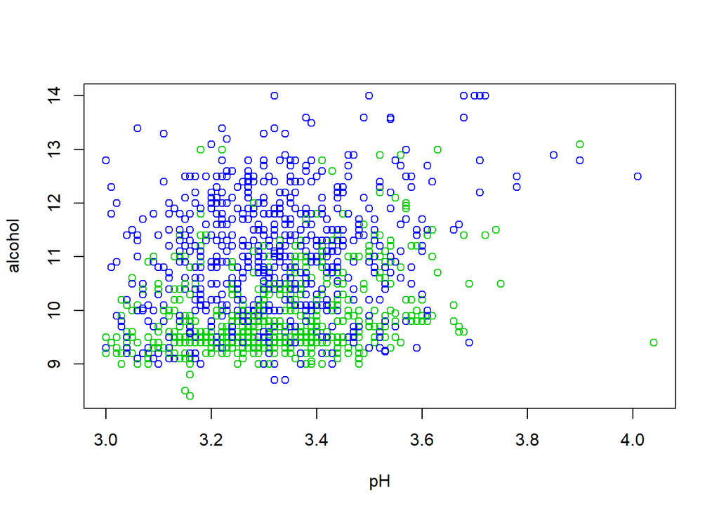

```r
with(wine_df, plot(pH, alcohol, col=high_quality+3))
```

En este caso, nuestra variable predictiva *high_quality*, representada por el color de los puntos, parece ser linealmente separable por la variable *alcohol*, pero no tanto por la variable *pH*.

Como afecta esto al modelo?

```r
model_log = glm(formula=high_quality ~ pH + alcohol,
                data = train_df, family=binomial(link="logit"))
model_log
```

```
##
## Call:  glm(formula = high_quality ~ pH + alcohol, family = binomial(link = "logit"),
##     data = train_df)
##
## Coefficients:
## (Intercept)           pH      alcohol
##      -6.494       -1.802        1.224
##
## Degrees of Freedom: 1183 Total (i.e. Null);  1181 Residual
## Null Deviance:       1634
## Residual Deviance: 1332  AIC: 1338
```

Nuevamente hemos entrenado el modelo con los datos de entrenamiento y calculamos el error con datos de entrenamiento, aunque no parece un score tan malo, veamos como se comporta el modelo:

```r
proba <- predict(model_log, x_test, type="response")
proba
```

```
##         6        12        18        26        42        44        45        57
## 0.2122222 0.5802107 0.3289289 0.2446040 0.2722169 0.5421210 0.2432268 0.4453332
##        68        69        71        75        77        79        80        82
## 0.6001988 0.6670091 0.3001309 0.3425081 0.4952925 0.4451737 0.2596027 0.3482718
##        84        86        97        98       101       111       114       115
## 0.3361010 0.4318605 0.1942201 0.4665995 0.2386824 0.3539326 0.4108013 0.2574554
##       121       122       123       129       130       131       132       133
## 0.2567422 0.2743133 0.3361010 0.9468446 0.9468446 0.3489732 0.4559463 0.3799136
##       138       140       141       151       155       160       163       167
## 0.3799136 0.9822625 0.2679276 0.4585661 0.5492066 0.4372069 0.3515225 0.4329354
##       170       171       179       181       183       184       185       192
## 0.2386824 0.8056287 0.3249625 0.1842078 0.3790343 0.2226932 0.3256404 0.3705872
##       202       210       213       219       221       227       228       232
## 0.2226932 0.5519785 0.5845945 0.3401348 0.4594934 0.6764622 0.8872173 0.1886405
##       235       240       243       245       246       248       254       256
## 0.2134734 0.4883106 0.2932533 0.2941619 0.3697167 0.4864448 0.2623589 0.3774299
##       260       262       265       266       267       271       275       278
## 0.4327769 0.7858450 0.9585021 0.1630065 0.4900154 0.2786660 0.4900154 0.3249625
##       282       285       290       291       303       305       315       319
## 0.3866695 0.5106763 0.5776373 0.4318605 0.3249625 0.3515225 0.5723200 0.3875554
##       320       321       327       331       338       342       343       348
## 0.2616369 0.3154901 0.3556422 0.7912332 0.2986998 0.7277196 0.2970029 0.4292722
##       352       357       359       360       363       366       367       374
## 0.9018567 0.4479423 0.3900640 0.5627143 0.5538246 0.9191303 0.3084156 0.9191303
##       376       383       396       402       409       410       415       416
## 0.6820163 0.2016179 0.3606440 0.4540944 0.2686606 0.8740332 0.5985606 0.2895316
##       422       424       432       440       452       457       463       464
## 0.9021297 0.6475527 0.3639456 0.5125423 0.3425081 0.9021867 0.4346111 0.7284589
##       466       468       472       476       477       482       485       495
## 0.6368443 0.3202078 0.5829367 0.3859373 0.3859373 0.6780945 0.9774662 0.9230596
##       496       498       503       505       507       517       522       528
## 0.9230596 0.7197658 0.8791443 0.5653102 0.9155978 0.3124121 0.1344429 0.4594934
##       530       534       535       537       540       541       542       546
## 0.3648104 0.3506717 0.7664149 0.8113104 0.6749672 0.6492553 0.2933871 0.6995305
##       548       553       556       560       567       573       578       581
## 0.9086776 0.4765129 0.1886405 0.7290694 0.3077573 0.6589546 0.7035747 0.3416677
##       583       587       588       599       600       601       606       614
## 0.2707399 0.4346111 0.3740778 0.2074832 0.4416469 0.4082486 0.3369347 0.1964663
##       621       622       623       626       627       631       633       636
## 0.3193955 0.3748012 0.3047212 0.5951220 0.2506242 0.2506242 0.4362883 0.8382978
```

[output cut: 43 more lines]

```
## 0.2486468 0.4108013 0.9448400 0.2852079 0.2852079 0.5758143 0.5758143 0.2926136
##      1324      1326      1327      1337      1348      1349      1353      1361
## 0.4327769 0.5106763 0.5106763 0.3952529 0.3824036 0.4381259 0.6621589 0.3344366
##      1366      1372      1382      1383      1384      1389      1390      1392
## 0.4479423 0.4133588 0.9423600 0.5562723 0.8541353 0.1975456 0.3756766 0.4524037
##      1393      1395      1399      1410      1413      1421      1428      1431
## 0.4336938 0.2679276 0.3506717 0.1462099 0.7448881 0.3216947 0.7437857 0.1650546
##      1433      1436      1437      1442      1448      1454      1455      1458
## 0.8901089 0.5456661 0.6701756 0.4505542 0.9767052 0.5924200 0.5286711 0.3336060
##      1464      1475      1478      1484      1487      1495      1496      1498
## 0.6810657 0.3866695 0.3295396 0.3327764 0.1748414 0.5793009 0.5545877 0.3498220
##      1499      1500      1507      1512      1514      1517      1535      1550
## 0.3344366 0.6897825 0.8411394 0.3522268 0.6733267 0.8183419 0.4855120 0.8449214
##      1554      1555      1556
## 0.7232578 0.8377032 0.3781558
```

```r
y_pred <- ifelse(proba > 0.5,1,0)
head(y_pred)
```

```
##  6 12 18 26 42 44
##  0  1  0  0  0  1
```

```r
head(y_test)
```

|  | high_quality |
| --- | --- |
| 6 | 0 |
| 12 | 0 |
| 18 | 0 |
| 26 | 0 |
| 42 | 0 |
| 44 | 0 |

En R, es mas preciso calcular el error usando los datos del test de prueba, ya que el score (R2) es calculado con el test de entrenamiento

```r
mean(y_pred != y_test)
```

```
## [1] 0.2919897
```

**Taller**  
Juegue un poco con las variables a incluir en el modelo para ver si logra aumentar el score del modelo y sus predicciones. Algunas sugerencias:

- Valide que variables permiten la separacion lineal de los datos
- Puede incluir mas de dos variables para entrenar el modelo, es lo mas recomendable, pero recuerde que no sera posible visualizar la separacion graficamente
- Intente con el parametro *family* de la funcion glm(), este permite generar otro tipo de lineas que pueden mejorar el modelo (Los posibles valores para el parametro y saber en detalle que tipo de modelo genera cada uno puede consultar [aqui](https://rpubs.com/JessicaP/459130). Tenga en cuenta GLM (General Lineal Model, puede generar todo tipo de models lineales y estamos buscando un modelo de *clasificacion binaria*)

Una vez encuentre un modelo que considere adecuado, vamos a a guardarlo para futuros laboratorios:

```r
saveRDS(model_log, file = "models/model_log.rds")
```

### Vecinos mas cercanos (kNN)

Es un metodo de clasificacion para problemas **no lineales**, y tal vez con una metodologia/matematica mas sencilla. Consiste en ver los datos como puntos en un plano (de N dimensiones cuantas variables incluya el modelo) y clasificar cualquier “punto nuevo” en la misma clase a la que pertenescan los *k* puntos mas cercanos (*k* puede ser definido por nosotros mismos)

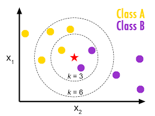

- **Precision:** Depende intensamente del valor de k. muy eficiente para datasets sin ruido
- **Velocidad:** Depende de dimensiones (*Realmente no construye ningon modelo*)
- **Explicativo:** Mucho (Es una ecuacion sencilla)
- **Sensible a cambios:** Mucho a atributos irrelevantes y la complejidad del modelo
- **Deteministico**: Si

```r
x_train = train_df[, !names(train_df) %in% c("high_quality")]
x_test = test_df[, !names(test_df) %in% c("high_quality")]
y_train = train_df$high_quality
y_test = test_df$high_quality
```

```r
y_pred <- knn(x_train, x_test, cl=y_train, k=18)
mean(y_pred != y_test)
```

```
## [1] 0.3255814
```

En este caso, se eligio el nomero de vecinos (k) aleatoriamente, y con razon no obtuvimos un score bueno. Pero cuidado:

- Si k es muy pequeño, tendiendo a 1, el modelo va a decidir por la clase del ejemplo mas cercano. Esto hace el modelo muy sensible al ruido o a pequeños cambios.
- Si k es muy grande, tendiendo a N, el modelo no podra gneralizar. Nunca analizara patrones, reglas, ni similitudes sino que decidira siempre *lo que diga la mayoria*

**Taller**  
Juegue un poco con el valor de k (*k* en la funcion *knn*) para mejorar el score del modelo.  
Tambien puede intentar eliminando aquellas variables que generen ruido o atipicos sobre los datos.

Una vez encuentre un modelo que considere adecuado, vamos a a guardarlo para futuros laboratorios:

```r
saveRDS(y_pred, file = "models/model_knn.rds")
```

### Maquinas de Soporte Vectorial (SVM)

Cuando hablamos de Regresion logistica, buscamos **una linea** que divida los datos de la mejor manera. Pero, que pasa cuando hay mas de una linea que cumple con esta condicion? Como elegir la mejor?  
Las maquinas de soporte vectorial buscan, por el contrario, un *hiperplano*: un conjunto de lineas que maximicen la distancia/margen entre los puntos mas cercanos de cada clase. A estos puntos mas cercanos se les conoce como *vectores de soporte*

[figure not shown]

- **Precision:** Alta si se configura correctamente
- **Velocidad:** Lento para una gran cantidad de datos
- **Explicativo:** No
- **Sensible a cambios:** Si, sobretodo a ejemplos mal etiquetados
- **Deteministico**: Si

```r
x_train = train_df[, !names(train_df) %in% c("high_quality")]
x_test = test_df[, !names(test_df) %in% c("high_quality")]
y_train = train_df$high_quality
y_test = train_df$high_quality
```

```r
model_svm <- svm(x_train, y_train, kernel='radial')
```

```r
probas <- predict(model_svm, x_test, decision.values = TRUE)
y_pred <- ifelse(probas > 0.5,1,0)
mean(y_pred != y_test)
```

```
## [1] 0.4949324
```

Aon tenemos un error un poco alto. Sin embargo, una de las ventajas de SVM, a pesar de ser un algoritmo lento y sensible al ruido, es su versatilidad para manejar problemas no lineales. Esto lo logra por medio del parametro **kernell** que permite definir “la forma” del/los hiperplano/s que va a generar:

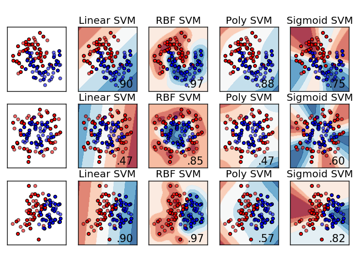

**Taller**  
Juegue un poco con las columas a incluir en el modelo, asi como con el **kernel** de la funcion *svm()*. Los posibles valores de este parametro son:

- ‘linear’
- ‘polynomial’ (En este caso tambien se puede configurar el parametro *degree*)
- ‘radial basis’ (rbf)
- ‘sigmoid’

Puede que enuentre varios modelos que le parezcan convenientes. Se sugiere guardar cada uno de la siguiente manera (cambiando el nombre del archivo):

```r
saveRDS(model_svm, file = "models/model_svm.rds")
```

### Árboles de Decision

Es el tipo de algoritmo mas facil de entender, pues se basa en reglas condicionales muy similares al lenguaje humano (*Si… entonces…*). El entrenamiento consiste en encontrar las reglas y condiciones que cubran la mayor cantidad de casos.  
El modelo graficamente puede ser representado mediante un arbol en el que los **nodos intermedios** son decisiones basadas en alguno de los atributos predictivos, y las **hojas** son la clase objetivo.

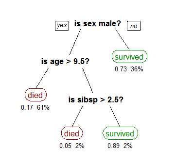

- **Precision:** Alta tendencia al sobreajuste (memorizar datos)
- **Velocidad:** Rapido. La validacion de reglas son condicionales
- **Explicativo:** Si
- **Sensible a cambios:** Si, pequeños cambios en los datos puede resultar en arboles completamente diferentes.
- **Deteministico**: No

```r
sample = sample.split(wine_df[,1], SplitRatio = .75)
train_df = subset(wine_df, sample == TRUE)
test_df  = subset(wine_df, sample == FALSE)
```

```r
model_tree <- rpart(high_quality ~ ., data = train_df, method = 'class')
```

```r
y_pred = data.frame(predict(model_tree, x_test, type="class"))
mean(y_pred != y_test)
```

```
## [1] 0.4883721
```

En cada uno de los nodos, el algoritmo valida que variable y que valor de esa variable produce un nivel mayor de “pureza” entre las hojas (*Entropia/gini index*). Si este nivel no es suficiente para dar una buena decision, se hace una nueva particion en cada una de las hojas, validando nuevamente todas las variables predictivas.

Por esto mismo, los arboles de decision tienen varios parametros que configurar (Nivel minimo de entropia, profundidad maxima del arbol, minima cantidad de muestras para las hojas, etc.)  
Otra de las ventajas de los arboles es que son **tan explicativos**, que pueden ser graficados para validar el proceso de toma de cada decision en el proceso de prediccion:

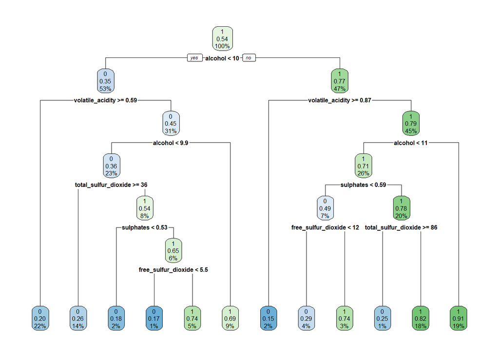

```r
rpart.plot(model_tree)
```

**Taller**  
Juegue un poco con las columas a incluir en el modelo, asi como con los parametros de la funcion *rpart()*. Para ello es necesario llamar la funcion *rpart.control()* y configurar algunos parametros como *max_depth, min_samples_split, min_samples_leaf, max_leaf_nodes, …*. Para mayor infirmacion puede consultar [aqui](https://www.rdocumentation.org/packages/rpart/versions/4.1-15/topics/rpart.control).

Una vez encuentre un modelo que considere adecuado, vamos a a guardarlo para futuros laboratorios:

```r
saveRDS(model_tree, file = "models/model_tree.rds")
```

### Ensambles de Modelos

Cuando un modelo es **no deterministico**, pero tiende al **sobreajuste**, es decir, aprende de memoria las reglas y patrones del set de entrenamiento, hasta el punto de no predecir correctamente sobre el test de entrenamiento, esto puede solucionarse haciendo un ensamble o conjunto de modelos. Esto es, construir varios modelos “debiles” y crear uno “robusto”, tomando la decision final dependiendo de:

- “Democracia”, el resultado es lo que diga la mayoria de modelos, realizando cada uno **bajo un set de entrenamiento diferente** (*bagging*)
- “Aleatorio”, el resultado es lo que diga la mayoria de arboles de decision, realizando cada uno con un set aleatorio de variables (*randomForest*)

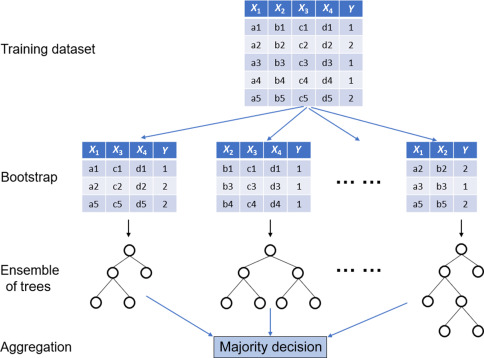

- **Precision:** Alta, varios modelos eliminan el sobreajuste
- **Velocidad:** Lento, por velocidad se sacrifica precision
- **Explicativo:** Si, aunque no entrega el modelo, entre importancia de variables
- **Sensible a cambios:** No mucho, un dato atipico peude modificar un arbol, pero no todos
- **Deteministico**: No

```r
sample = sample.split(wine_df[,1], SplitRatio = .75)
train_df = subset(wine_df, sample == TRUE)
train_df$high_quality <- as.factor(train_df$high_quality)
test_df  = subset(wine_df, sample == FALSE)
```

```r
model_forest <- randomForest(high_quality ~ ., data = train_df,
                             type = 'classification', ntree=20)
y_pred = data.frame(predict(model_forest, x_test))
mean(y_pred != y_test)
```

```
## [1] 0.503876
```

Note que, si la anterior celda se ejecuta varias veces, cada vez da un valor diferente. Esto significa que el modelo es **no deterministico**. Aunque el error cambie con solo ejecutarlo, es mejor configurar algunos parametros para indicarle al modelo por donde esta la mejor solucion.  
El concenso realizado entre los modelos permite al algoritmo, a pesar de ser no deterministico, darse una idea de la importancia de cada variable en la toma de la decision:

```r
imp = importance(model_forest)
imp
```

```
##                      MeanDecreaseGini
## fixed_acidity                37.21263
## volatile_acidity             62.44334
## citric_acid                  35.73411
## residual_sugar               30.23166
## chlorides                    44.02320
## free_sulfur_dioxide          35.63569
## total_sulfur_dioxide         56.15126
## density                      44.91798
## pH                           39.71718
## sulphates                    74.25979
## alcohol                     128.26465
```

**Taller**  
Juegue un poco con las columnas a incluir en el modelo, en este caso revise la importancia de variables.  
Puede tambien jugar con los parametros de la funcion *randomForest()*, como *ntree* (Cantidad de modelos/arboles a generar), *maxnodes. nodesize, etc.*

Una vez encuentre un modelo que considere adecuado, vamos a a guardarlo para futuros laboratorios:

```r
saveRDS(model_tree, file = "models/model_tree.rds")
```